# RNA-sequencing

Carissa Eijking en Jorge Vargas Centeno

## **Introductie**

**Hersenziekten**, zoals bijvoorbeeld de ziekte van Parkinson, worden veroorzaakt door verstoorde functie van hersencellen. De exacte moleculaire mechanismen zijn vaak onbekend, waardoor het heel waardevol zou zijn om deze cellen in een laboratorium te kunnen onderzoeken. Echter is het niet mogelijk om het hersenweefsel van een levend persoon te bestuderen. Als oplossing kunnen hersencellen gemaakt worden uit **fibroblasten**.

Fibroblasten kunnen worden omgezet naar geïnduceerde pluripotente stamcellen (iPSCs) en vervolgens kunnen deze differentiëren naar hersencellen. Dit kost echter veel tijd. Hierdoor is een alternatieve methode het direct omzetten van fibroblasten naar hersencellen door overexpressie van bepaalde transcriptiefactoren. Dit heet *transdifferentiatie*.

Voor deze opdracht maken we gebruik van gepubliceerde data waarin fibroblasten van een proefpersoon werden behandeld met een *controle transcriptiefactor (BCLXL)* of de *transcriptiefactor (ONECUT2)*. Van ONECUT2 wordt vermoed dat het fibroblasten naar hersencellen kan omzetten. Er werden verschillende RNA-seq datasets voor elke fibroblast gegenereerd, waarbij elke conditie *(celtype)* in duplo werd gemeten.

## **Experiment**

### *Onderzoeksvraag*

**Wat zijn de verschillen in genexpressie tussen BCLXL behandelde fibroblasten en ONECUT2 behandelde fibroblasten?**

### *Informatie over het experiment*

**Cel type:** **Fibroblasten uit de huid van de proef persoon**

**Genome:** Homo sapiens (h38)

**DNA type:** Paired end sequencing DNA

**Sequencing machine:** Illumina NextSeq 500

### *Samples*

| Run | Assay Type | AvgSpotLen | Bases | BioProject | BioSample | Bytes | Cell_line | Cell_type | Center Name | Consent | DATASTORE filetype | DATASTORE provider | DATASTORE region | Experiment | GEO_Accession (exp) | Instrument | LibraryLayout | LibrarySelection | LibrarySource | Organism | Platform | ReleaseDate | Sample Name | source_name | SRA Study |
| --- | --- | --- | --- | --- | --- | --- | --- | --- | --- | --- | --- | --- | --- | --- | --- | --- | --- | --- | --- | --- | --- | --- | --- | --- | --- |
| SRR7866699 | RNA-Seq | 86 | 1594016622 | PRJNA491516 | SAMN10079869 | 662419376 | Fibroblast line 1 (CL1500023) | Skin derived fibroblast overexpressing Bclxl | GEO | public | fastq,sra | gs,ncbi,s3 | gs.US,ncbi.public,s3.us-east-1 | SRX4705879 | GSM3393013 | NextSeq 500 | PAIRED | cDNA | TRANSCRIPTOMIC | Homo sapiens | ILLUMINA | 2019-04-05 | GSM3393013 | Fibroblast line 1 | SRP161949 |
| SRR7866700 | RNA-Seq | 86 | 4004919208 | PRJNA491516 | SAMN10079867 | 1664172935 | Fibroblast line 1 (CL1500023) | Skin derived fibroblast overexpressing Bclxl | GEO | public | fastq,sra | gs,ncbi,s3 | gs.US,ncbi.public,s3.us-east-1 | SRX4705880 | GSM3393014 | NextSeq 500 | PAIRED | cDNA | TRANSCRIPTOMIC | Homo sapiens | ILLUMINA | 2019-04-05 | GSM3393014 | Fibroblast line 1 | SRP161949 |
| SRR7866703 | RNA-Seq | 86 | 1463740124 | PRJNA491516 | SAMN10079862 | 609596603 | Fibroblast line 1 (CL1500023) | 2 days after induction of OC2 in skin derived fibroblasts | GEO | public | fastq,sra | gs,ncbi,s3 | gs.US,ncbi.public,s3.us-east-1 | SRX4705883 | GSM3393017 | NextSeq 500 | PAIRED | cDNA | TRANSCRIPTOMIC | Homo sapiens | ILLUMINA | 2019-04-05 | GSM3393017 | Fibroblast line 1 | SRP161949 |
| SRR7866704 | RNA-Seq | 86 | 1520247972 | PRJNA491516 | SAMN10079861 | 637413046 | Fibroblast line 1 (CL1500023) | 2 days after induction of OC2 in skin derived fibroblasts | GEO | public | fastq,sra | gs,ncbi,s3 | gs.US,ncbi.public,s3.us-east-1 | SRX4705884 | GSM3393018 | NextSeq 500 | PAIRED | cDNA | TRANSCRIPTOMIC | Homo sapiens | ILLUMINA | 2019-04-05 | GSM3393018 | Fibroblast line 1 | SRP161949 |

## **Resultaten van de fastQC html rapporten**

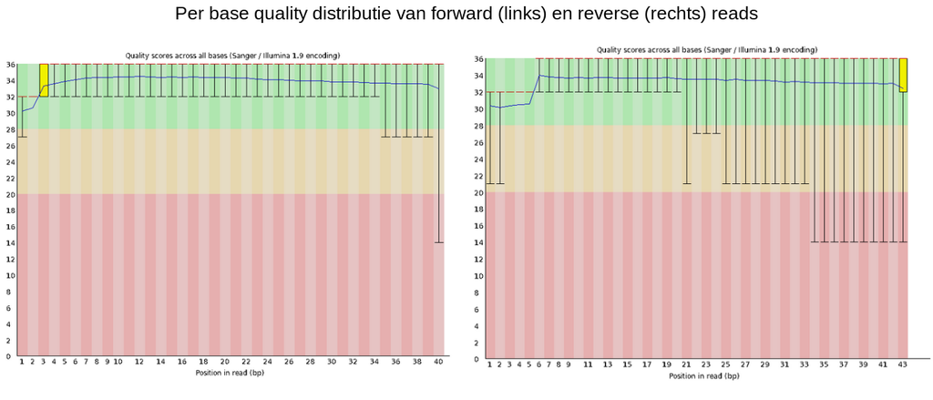

Fig. 1: Kwaliteit distributie: links is de per base quality zichtbaar van de forward read en rechts van de Reverse read. De Phred scores gaan van 0 tot 36.

## **Count table**

De alignment van de dataset met het referentiegenoom is al uitgevoerd. De ontstane bam-bestanden geven voor alle RNA-seq fragmenten de genomische locatie in het referentie genoom weer en bevatten de alignment scores en kunnen hierdoor gebruikt worden om te bepalen welke genen tot expressie zijn gebracht. Door gebruik van de bam-bestanden, willen we tellen voor elk gen hoeveel fragmenten uitlijnen tegenover dat gen in het BCLXL behandelde monster of ONECUT behandelde monster. Dit is belangrijk voor de **differentiële expressieanalyse**, aangezien dit zal dienen als input.

We kunnen deze “count” tabel maken m.b.v het Rsubread-pakket: **featureCounts().**

### *Count tabel*

```r
# Maak een object met de directory van bam bestanden
bam_dir <- "/home/daur2/rnaseq/rnaseq_onecut/bam"

# Maak een object met output dir voor count tables
counts_dir <- "~/daur2/RNA_sequencing/data/count_tables"

# Create vector with names of bam files
bam_files <- list.files(bam_dir, pattern = "SRR7866[6,7]{1}[09]{1}[034]{1}\\.bam$", full.names = TRUE)

# Count the reads per gene using the in-built NCBI RefSeq annotations
read_counts <- featureCounts(

  files = bam_files,
  annot.inbuilt = "hg38",
  useMetaFeatures = TRUE,
  strandSpecific = 0,
  isPairedEnd = TRUE,
  countReadPairs = TRUE,
  nthreads = 10
)
```

Nu dat de count tabel is gemaakt, kan de statistieke analyse worden uitgevoerd.

### *Count tabel (statistieken)*

```r
#Load read counts
counts <- readRDS("/home/daur2/rnaseq/rnaseq_onecut/counts/read_counts_OC2.rds")

#Inspect count table
str(counts)
```

```
## List of 4
##  $ counts    : int [1:28395, 1:4] 0 27 0 0 0 0 0 0 46 2 ...
##   ..- attr(*, "dimnames")=List of 2
##   .. ..$ : chr [1:28395] "100287102" "653635" "102466751" "100302278" ...
##   .. ..$ : chr [1:4] "SRR7866699.bam" "SRR7866700.bam" "SRR7866703.bam" "SRR7866704.bam"
##  $ annotation:'data.frame':  28395 obs. of  6 variables:
##   ..$ GeneID: int [1:28395] 100287102 653635 102466751 100302278 645520 79501 729737 102725121 102723897 102465909 ...
##   ..$ Chr   : chr [1:28395] "chr1;chr1;chr1" "chr1;chr1;chr1;chr1;chr1;chr1;chr1;chr1;chr1;chr1;chr1" "chr1" "chr1" ...
##   ..$ Start : chr [1:28395] "11874;12613;13221" "14362;14970;15796;16607;16858;17233;17606;17915;18268;24738;29321" "17369" "30366" ...
##   ..$ End   : chr [1:28395] "12227;12721;14409" "14829;15038;15947;16765;17055;17368;17742;18061;18366;24891;29370" "17436" "30503" ...
##   ..$ Strand: chr [1:28395] "+;+;+" "-;-;-;-;-;-;-;-;-;-;-" "-" "+" ...
##   ..$ Length: int [1:28395] 1652 1769 68 138 1130 918 5474 1173 2120 68 ...
##  $ targets   : chr [1:4] "SRR7866699.bam" "SRR7866700.bam" "SRR7866703.bam" "SRR7866704.bam"
##  $ stat      :'data.frame':  14 obs. of  5 variables:
##   ..$ Status        : chr [1:14] "Assigned" "Unassigned_Unmapped" "Unassigned_Read_Type" "Unassigned_Singleton" ...
##   ..$ SRR7866699.bam: int [1:14] 11390881 3166819 0 0 0 0 0 0 0 0 ...
##   ..$ SRR7866700.bam: int [1:14] 26636954 8778629 0 0 0 0 0 0 0 0 ...
##   ..$ SRR7866703.bam: int [1:14] 10042397 3111074 0 0 0 0 0 0 0 0 ...
##   ..$ SRR7866704.bam: int [1:14] 9165415 3495943 0 0 0 0 0 0 0 0 ...
```

```r
#Pakt de statieken van de lijst af.
counts_stats <- counts$stat

#Verwijderd status kolom
##convert first column to rownames
rownames(counts_stats) <- counts_stats$Status
##Zet de status kolom naar NULL
counts_stats$Status <- NULL

#Tidy maken
counts_stats_t <- counts_stats %>%
  t %>%
  as.tibble() %>%
  mutate(bamfile=colnames(counts_stats),
         totaal=colSums(counts_stats),
         perc_assign_frags=Assigned/totaal*100)
```

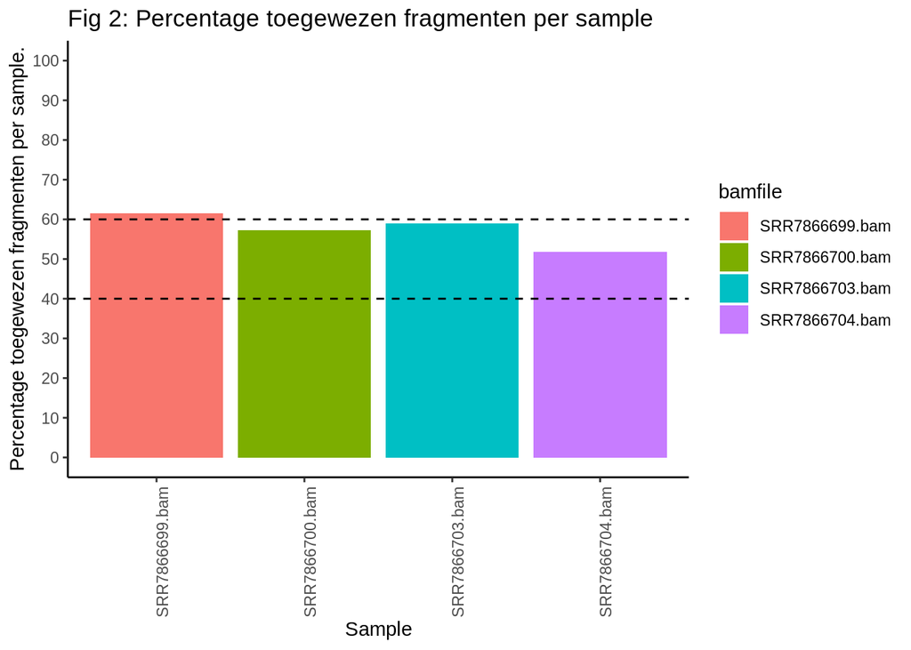

```r
#Plot de percentage assign reads
counts_stats_t %>% ggplot(aes(x=bamfile, y=perc_assign_frags,
                              group=bamfile, fill=bamfile)) +
  geom_col() +
  geom_hline(yintercept = 60, linetype= "dashed") +
  geom_hline(yintercept = 40, linetype = "dashed") +
  theme_classic() +
  theme(axis.text.x = element_text(angle = 90)) + #Zet de naam van de het bestand in verticaal
  scale_y_continuous(breaks = seq(0, max(100), by = 10)) + #Veranderd de stappen van de y-axis
  coord_cartesian(ylim=c(0,100))+
  labs(
    title="Fig 2: Percentage toegewezen fragmenten per sample",
    x="Sample",
    y="Percentage toegewezen fragmenten per sample."
  )
```

**Discussie:** Een mogelijk reden voor deze lage percentages gebonden fragmenten, is een mogelijke contaminatie van DNA in de monsters tijdens de uitvoering van dit experiment. Dit zal zorgen dat een redelijke aantal RNA fragmenten aan dit contaminatie DNA binden, waardoor ze niet correct kunnen worden geïnterpreteerd als *toegewezen fragmenten.* Ook kan het zijn dat dit DNA juist gezien wordt als RNA dat zich niet kon uitlijnen tegenover het referentie genoom. Dit verlaagt dan ook het percentage toegewezen fragmenten.

## **DESeq2 analyse**

### *Omzetten van de “count tabel” naar een DESeq object*

Voordat de functies in het DESeq2-pakket gebruikt kunnen worden, moet eerst de “count tabel” omgezet worden naar een DESeq-object.

Hiervoor zijn de volgende “inputs” nodig:

1. Een matrix met het aantal fragmenten voor elk gen per monster (the count table).
2. Een dataframe waarin voor elk monster in de matrix (kolommen in de matrix) de experimentele details worden gedetailleerd.
3. Een formule die de experimentele opzet gedetailleerd.(Dus welke monsters moeten worden vergeleken om het verschil in genexpressieniveaus te vinden).

#### *1. “Count matrix” verkrijgen*

```r
# Count matrix
count_matrix <- counts$counts
```

#### *2. Creëren van een datafram met metadata*

```r
#Import sample data
metadata <- read_csv("/home/daur2/rnaseq/rnaseq_onecut/onecut_sampledata_OC2.csv")

#Omzet de metadata naar een dataframe
metadata <- as.data.frame(metadata)

#Voeg rijnamen naar de metadata dataframe
rownames(metadata) <- paste0(metadata$Run, ".bam")

#Check de eerste lijnen van de metadata object
head(metadata)
```

```
##                       Run Assay Type AvgSpotLen      Bases  BioProject
## SRR7866699.bam SRR7866699    RNA-Seq         86 1594016622 PRJNA491516
## SRR7866700.bam SRR7866700    RNA-Seq         86 4004919208 PRJNA491516
## SRR7866703.bam SRR7866703    RNA-Seq         86 1463740124 PRJNA491516
## SRR7866704.bam SRR7866704    RNA-Seq         86 1520247972 PRJNA491516
##                   BioSample      Bytes                     Cell_line
## SRR7866699.bam SAMN10079869  662419376 Fibroblast line 1 (CL1500023)
## SRR7866700.bam SAMN10079867 1664172935 Fibroblast line 1 (CL1500023)
## SRR7866703.bam SAMN10079862  609596603 Fibroblast line 1 (CL1500023)
## SRR7866704.bam SAMN10079861  637413046 Fibroblast line 1 (CL1500023)
##                                                                Cell_type
## SRR7866699.bam              Skin derived fibroblast overexpressing Bclxl
## SRR7866700.bam              Skin derived fibroblast overexpressing Bclxl
## SRR7866703.bam 2 days after induction of OC2 in skin derived fibroblasts
## SRR7866704.bam 2 days after induction of OC2 in skin derived fibroblasts
##                Center Name Consent DATASTORE filetype DATASTORE provider
## SRR7866699.bam         GEO  public          fastq,sra         gs,ncbi,s3
## SRR7866700.bam         GEO  public          fastq,sra         gs,ncbi,s3
## SRR7866703.bam         GEO  public          fastq,sra         gs,ncbi,s3
## SRR7866704.bam         GEO  public          fastq,sra         gs,ncbi,s3
##                              DATASTORE region Experiment GEO_Accession (exp)
## SRR7866699.bam gs.US,ncbi.public,s3.us-east-1 SRX4705879          GSM3393013
## SRR7866700.bam gs.US,ncbi.public,s3.us-east-1 SRX4705880          GSM3393014
## SRR7866703.bam gs.US,ncbi.public,s3.us-east-1 SRX4705883          GSM3393017
## SRR7866704.bam gs.US,ncbi.public,s3.us-east-1 SRX4705884          GSM3393018
##                 Instrument LibraryLayout LibrarySelection  LibrarySource
## SRR7866699.bam NextSeq 500        PAIRED             cDNA TRANSCRIPTOMIC
## SRR7866700.bam NextSeq 500        PAIRED             cDNA TRANSCRIPTOMIC
## SRR7866703.bam NextSeq 500        PAIRED             cDNA TRANSCRIPTOMIC
## SRR7866704.bam NextSeq 500        PAIRED             cDNA TRANSCRIPTOMIC
##                    Organism Platform ReleaseDate Sample Name       source_name
## SRR7866699.bam Homo sapiens ILLUMINA  2019-04-05  GSM3393013 Fibroblast line 1
## SRR7866700.bam Homo sapiens ILLUMINA  2019-04-05  GSM3393014 Fibroblast line 1
## SRR7866703.bam Homo sapiens ILLUMINA  2019-04-05  GSM3393017 Fibroblast line 1
## SRR7866704.bam Homo sapiens ILLUMINA  2019-04-05  GSM3393018 Fibroblast line 1
##                SRA Study
## SRR7866699.bam SRP161949
## SRR7866700.bam SRP161949
## SRR7866703.bam SRP161949
## SRR7866704.bam SRP161949
```

```r
#Controleert dat de kolommen van de count matrix en rijen van de metadata dezelfde namen hebben.
colnames(count_matrix) == rownames(metadata)
```

```
## [1] TRUE TRUE TRUE TRUE
```

#### *3. Creëren van een formule met experimentele opzet*

```r
#Creëert een kolom met de test conditie
metadata <- metadata %>%  mutate(treatment = str_replace(Cell_type, "Skin derived fibroblast overexpressing Bclxl", "BCLXL") %>%
           str_replace("2 days after induction of OC2 in skin derived fibroblasts", "ONECUT2"))

metadata$treatment <- metadata$treatment %>% factor(levels = c("BCLXL", "ONECUT2"))
```

Alle “inputs” zijn gegenereerd, waardoor het DESeqDataset object gemaakt kan worden.

#### *Maak een DESeq object*

```r
#Creëert een DESeqDataset object
dds <- DESeqDataSetFromMatrix(
  countData = count_matrix,
  colData = metadata,
  design = ~ treatment
)
```

## **RNASeq data normaliseren**

Voordat de kwaliteit van RNA-sequencing data gecontroleerd kan worden, moet de data genormaliseerd worden. Normalisatie van data is belangrijk, omdat het helpt om de variabiliteit in de data te corrigeren en ervoor te zorgen dat de analyses juist zijn. Het maakt het ook makkelijker om te zien welke genen upgereguleerd of downgereguleerd worden na de verschillende behandelingen, in dit geval: *“Fibroblasten behandeld met BCLXL”* en *“Fibroblasten behandeld met ONECUT2”*

```r
dds_normalized <- rlog(dds)
```

## **Kwaliteitscontrole**

### *Principal component analysis*

Het aantal genen in deze dataset is 28.395. Dit is vrij lastig weer te geven en te analyseren. Hierdoor wordt principal component analysis *(PCA)* uitgevoerd. Het is een methode die het aantal variabelen, in dit geval de genen, te verkleinen door middel van een aantal lineaire combinaties. De grootste spreiding genen wordt dan gevangen in een eerste variabele, principal component 1 (PC1). Dit gaat dan door tot alle genen zijn samengevat. Zo kan de scheiding van de genen gebaseerd op genexpressie duidelijker weergegeven worden.

```r
#Uitvoert PCA methode met de genormaliseerd data
pca <- dds_normalized %>% assay() %>% t() %>% prcomp()
```

De PCA analyse geeft in dit geval 4 nieuwe variabelen. Om te bekijken hoeveel van data elke PC representeert wordt de *summary()* function gebruikt.

```r
pca_summary <- summary(pca)$importance
pca_summary
```

```
##                             PC1      PC2      PC3          PC4
## Standard deviation     61.88936 11.27333 9.645877 3.929031e-13
## Proportion of Variance  0.94565  0.03138 0.022970 0.000000e+00
## Cumulative Proportion   0.94565  0.97703 1.000000 1.000000e+00
```

- PC1 representeert 94.6% van de variatie.
- PC2 representeert 3,1% van de variatie.
- PC3 representeert 2.3% van de variatie.
- PC4 representeert afgerond 0% van de variatie.

#### *Hypothese*

1. Er wordt verwacht dat er een verschil is in genexpressie tussen de **fibroblasten behandeld met BCLXL** en de **fibroblasten behandeld met ONECUT2**. Dit zal zorgen voor een grotere afstand op de x-as tussen deze genen.
2. Aangezien de gebruikte cellijn voor elke behandeling hetzelfde is, zullen er geen verschillen zijn genexpressie afkomstig door verschillende cellijnen. De afstand op de y-as zal dan klein zijn.

#### *Plot de principal components*

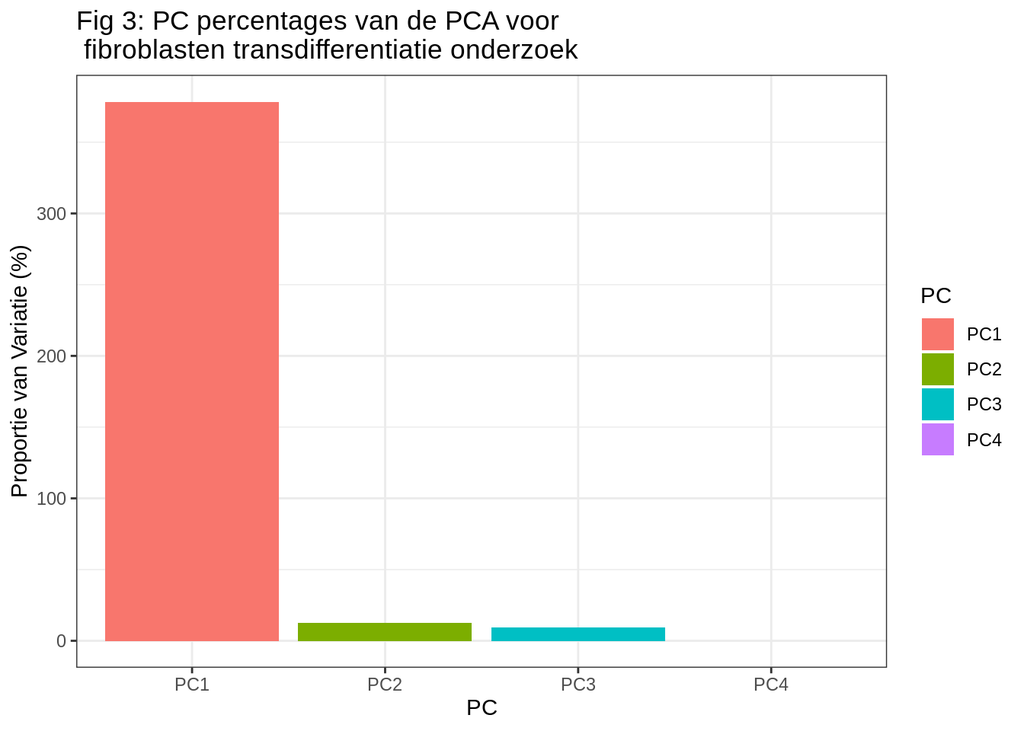

```r
#Maak een data frame met metadata en PCA waardes
pca_plotting <- cbind(metadata, pca$x)

# Verkrijg de percentages van PCs
PC1_var <- round(pca_summary["Proportion of Variance", "PC1"]*100, digits = 1)
PC2_var <- round(pca_summary["Proportion of Variance", "PC2"]*100, digits = 1)
PC3_var <- round(pca_summary["Proportion of Variance", "PC3"]*100, digits = 1)
PC4_var <- round(pca_summary["Proportion of Variance", "PC4"]*100, digits = 1)

# Voeg de percentages toe aan de data frame
percentages <- c(PC1_var, PC2_var, PC3_var, PC4_var)
df <- tibble(PC = c("PC1","PC2","PC3","PC4"), Percentage=percentages)
pca_plotting2 <- merge(pca_plotting, df)

# Plot de PC variabelen in een staafdiagram
ggplot(pca_plotting2) +
  geom_col(aes(x=PC, y=Percentage, fill = PC)) +
  ggtitle("Fig 3: PC percentages van de PCA voor \n fibroblasten transdifferentiatie onderzoek") +
  xlab("PC") +
  ylab("Proportie van Variatie (%)") +
  theme_bw()
```

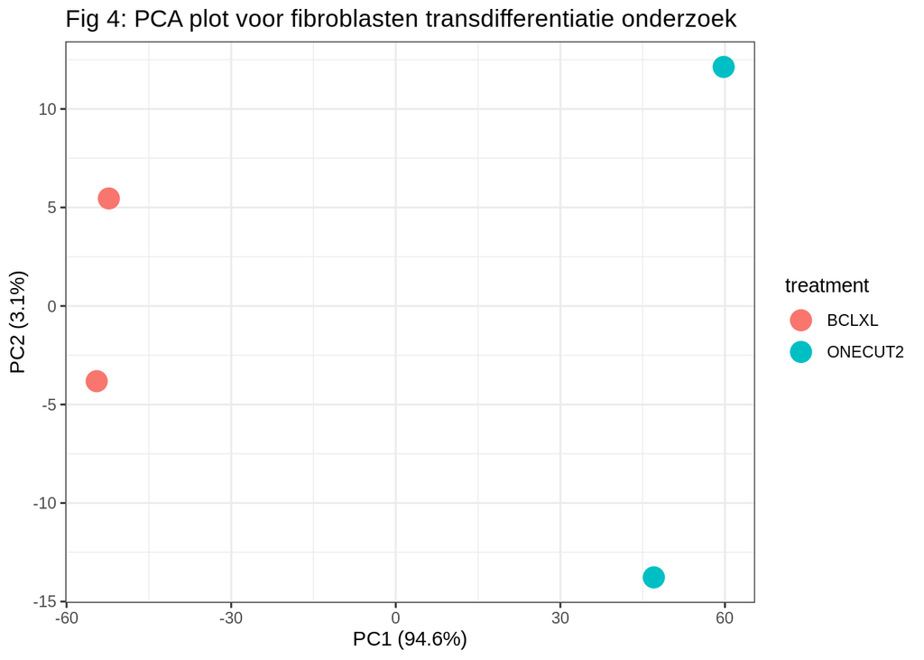

```r
#Plot PC1 vs PC2
ggplot(pca_plotting) +
  geom_point(aes(x=PC1, y=PC2, color = treatment), size = 5) +
  ggtitle("Fig 4: PCA plot voor fibroblasten transdifferentiatie onderzoek") +
  xlab(paste0("PC1 (", PC1_var, "%)")) +
  ylab(paste0("PC2 (", PC2_var, "%)")) +
  theme_bw()
```

Op basis van de resultaten van *figuur 4* kan geconclueerd worden dat er een groot verschil is in de genexpressie tussen de *“Fibroblasten behandeld met BCLXL”* en *“Fibroblasten behandeld met ONECUT2”*. Hierdoor is er een grote afstand zichtbaar tussen de fibroblasten op de x-as. Dit komt overeen met de hypothese.

## **Differential gene expression analysis**

Er moet uiteindelijk bekeken worden wat het verschil is in genexpressie tussen *“Fibroblasten behandeld met BCLXL”* en *“Fibroblasten behandeld met ONECUT2”*. Hiervoor wordt gebruik gemaakt van een “Differential Gene Expression (DGE)” analyse. In een DGE analyse wordt gezocht naar een set genen met een ander expressie profiel ten opzichte van een andere conditie. Deze genen zijn dan “differentially expressed (DE)”. Hiertoe wordt gekeken naar significantie en dus p-waarden.

Een p-waarde geeft weer of er een significant verschil aanwezig is tussen twee condities. In een DGE-analyse moet de p-waarde voor elk gen berekend worden. In dit geval 28.395 genen. Hiervoor moeten de p-waarden worden gecorrigeerd. De output van het DESeq2-pakket geeft zowel ongecorrigeerde *p-values*, als gecorrigeerde p-waardes *padj* (p-adjusted).

## **Uitvoering van DGE analyse**

```r
# Uitvoer DGE analyse
fibroblasten_dge <- DESeq(dds)
```

Na de uitvoering van de DGE analyse, kunnen de resultaten van de DGE analyse bekeken worden met behulp van de **results()* functie.

```r
#Verkrijgt de resultaten van de DGE Analyse.
fibroblasten_dge_results <- results(fibroblasten_dge, alpha = 0.01, lfcThreshold = 1)
fibroblasten_dge_results
```

```
## log2 fold change (MLE): treatment ONECUT2 vs BCLXL
## Wald test p-value: treatment ONECUT2 vs BCLXL
## DataFrame with 28395 rows and 6 columns
##            baseMean log2FoldChange     lfcSE      stat    pvalue      padj
##           <numeric>      <numeric> <numeric> <numeric> <numeric> <numeric>
## 100287102  0.291515        2.01194  4.994657  0.202605  0.839443        NA
## 653635    55.628148        1.69718  0.553242  1.260175  0.207606   0.60893
## 102466751  0.944964        3.66494  4.484966  0.594193  0.552383        NA
## 100302278  0.000000             NA        NA        NA        NA        NA
## 645520     0.000000             NA        NA        NA        NA        NA
## ...             ...            ...       ...       ...       ...       ...
## 105379557         0             NA        NA        NA        NA        NA
## 105379559         0             NA        NA        NA        NA        NA
## 105379561         0             NA        NA        NA        NA        NA
## 102723822         0             NA        NA        NA        NA        NA
## 102723891         0             NA        NA        NA        NA        NA
```

```r
#Verkrijgt een samenvatting van de resultaten.
summary(fibroblasten_dge_results)
```

```
##
## out of 21837 with nonzero total read count
## adjusted p-value < 0.01
## LFC > 1.00 (up)    : 1753, 8%
## LFC < -1.00 (down) : 939, 4.3%
## outliers [1]       : 0, 0%
## low counts [2]     : 5834, 27%
## (mean count < 4)
## [1] see 'cooksCutoff' argument of ?results
## [2] see 'independentFiltering' argument of ?results
```

Met deze samenvatting kan gezien worden dat ongeveer 1753 genen upgereguleerd zijn en ongeveer 939 genen downreguleerd zijn als gevolg van de behandeling van fibroblasten met ONECUT2 ten opzichte van BCLXL.

## **Visualisatie van de DGE resultaten.**

Om de resultaten van de DGE analyse te visualiseren, worden gebruik gemaakt van volcano plots en heatmaps.

### *Volcano Plots*

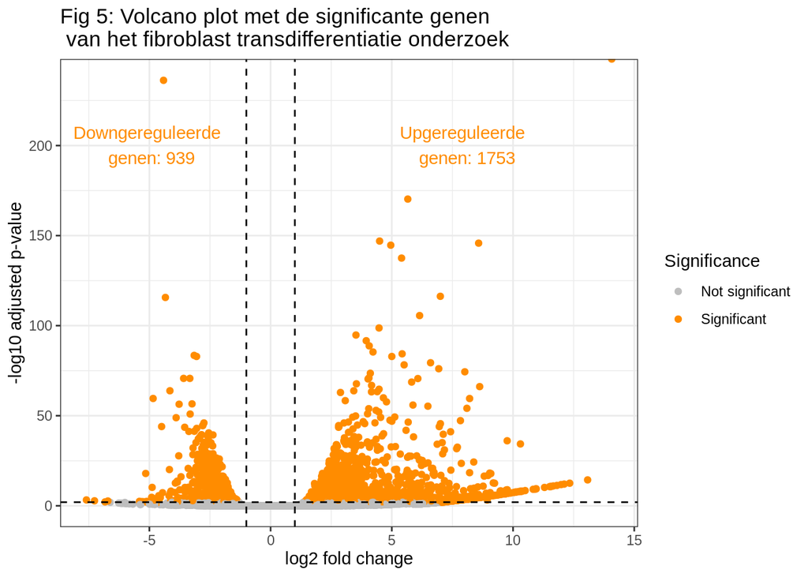

```r
# Creert een dataframe voor plotting without genes with NA's values
fibroblasten_dge_plotting <- data.frame(fibroblasten_dge_results) %>% filter(!is.na(padj))

# Maak een kolom waar je vertelt of het gen een significante verschil heeft.
fibroblasten_dge_plotting <- fibroblasten_dge_plotting %>%
  mutate(signif = if_else(padj < 0.01 & abs(log2FoldChange) > 1, "Significant", "Not significant"))

# Maak objecten met het aantal upgereguleerde en downgereguleerd genen

up_genen <- fibroblasten_dge_plotting %>%  filter(padj < 0.01 & log2FoldChange > 1) %>%  nrow()

down_genen <- fibroblasten_dge_plotting %>% filter(padj < 0.01 & log2FoldChange < -1) %>% nrow()

# Maak een volcano plot
fibroblasten_dge_plotting %>%
  ggplot(aes(x = log2FoldChange, y = -log10(padj), color = signif)) +
  geom_point() +
  geom_vline(xintercept = 1, linetype="dashed") +
  geom_vline(xintercept = -1, linetype="dashed") +
  geom_hline(yintercept = -log10(0.01), linetype="dashed") +
  xlab("log2 fold change") +
  ylab("-log10 adjusted p-value") +
  ggtitle("Fig 5: Volcano plot met de significante genen \n van het fibroblast transdifferentiatie onderzoek")+
  theme_bw() +

  # Veranderd de legende van de tekst en kleur
  scale_colour_manual(values = c("grey", "darkorange"), name = "Significance") +

  # het aantal upgereguleerde en downgereguleerd genen
 annotate("text", x = -5, y = 200,
           label = paste("Downgereguleerde \n genen:", down_genen ), colour = "darkorange") +

  annotate("text", x = 8, y = 200,
           label = paste("Upgereguleerde \n genen:", up_genen ), colour = "darkorange")
```

### *Heatmaps*

Een heatmap wordt gebruikt om te zien welke genen zijn *up- en downgereguleerd* tijdens het *transdifferentiatie proces*. Hiervoor worden eerst de **top 5 up- en downgereguleerde genen** geselecteerd en vervolgens geplot in een heatmap.

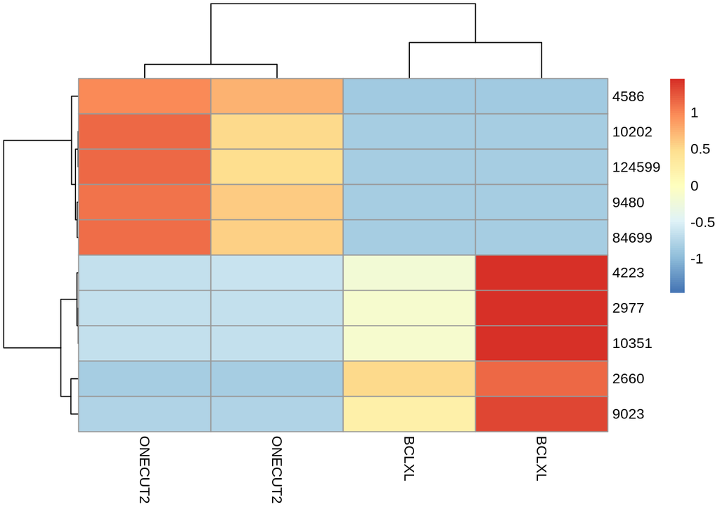

```r
#Verkrijgt genen met een significante p-waarde
sign_genes <- fibroblasten_dge_results[which(fibroblasten_dge_results$padj < 0.01),]

# Verkrijgt de 5 meeste significante upgenen
top5_upgenen <- rownames(sign_genes[order(sign_genes$log2FoldChange, decreasing = TRUE)[1:5], ])

# Verkrijgt de 5 meeste significante downgenen
top5_downgenen <- rownames(sign_genes[order(sign_genes$log2FoldChange, decreasing = FALSE)[1:5], ])

# Combinneer de twee top 5 genen in een object
top_genen <- c(top5_upgenen, top5_downgenen)

# Verkrijgt de count values voor de top 5 upgenen
count_values <- assay(dds)[top_genen,]

# Vervang de kolom namen met de condities
colnames(count_values) <- colData(dds)$treatment

# Visualiseert de resultaten in een heatmap( genormaliseerd)
pheatmap(count_values, scale = "row", show_rownames = TRUE)
```

### *Ontdekt welke genen veranderen*

De **top 5 up- en downgereguleerde genen** zijn nu gevonden. Echter zijn alleen de *Entrez-identificatienummers* voor deze genen zichtbaar. Aangezien dit niet veel informatie verschaft, worden de gen symbolen aangegeven door middel van de Entrex-identificatienummers m.b.v de *mapIds() functie*.

#### *mapIds(functie)*

Deze functie wordt gebruikt om identificatienummers van genen of eiwitten om te zetten naar andere identificatienummers of annotaties, zoals het omzetten van Entrez-genen naar symbolen of omgekeerd.

Bijvoorbeeld als je een lijst hebt met Entrez-gen-ID’s en je wilt de corresponderende gen-symboolnamen verkrijgen, kun je mapIds() gebruiken om deze conversie uit te voeren. Dit maakt gebruik van een annotatie-database die beschikbaar is in pakketten zoals org.Hs.eg.db (voor menselijke genen).

```r
# Omzet de 5 meeste significante upgenen in een dataframe
top5_upgenen <- sign_genes[order(sign_genes$log2FoldChange, decreasing = TRUE)[1:5],] %>% as.data.frame()

# Omzet de 5 meeste significante downgenen in een dataframe
top5_downgenen <- sign_genes[order(sign_genes$log2FoldChange, decreasing = FALSE)[1:5],] %>% as.data.frame()

# Combinneer de twee top 5 genen in een dataframe
top_genen <- rbind(top5_upgenen, top5_downgenen)

knitr::kable(head(top_genen))
```

|  | baseMean | log2FoldChange | lfcSE | stat | pvalue | padj |
| --- | --- | --- | --- | --- | --- | --- |
| 9480 | 115058.28782 | 14.07113 | 0.2713296 | 48.174366 | 0.00e+00 | 0.0000000 |
| 10202 | 641.40527 | 13.07618 | 1.4569029 | 8.288937 | 0.00e+00 | 0.0000000 |
| 124599 | 384.23590 | 12.33705 | 1.4621299 | 7.753788 | 0.00e+00 | 0.0000000 |
| 84699 | 328.38463 | 12.11039 | 1.4628460 | 7.595050 | 0.00e+00 | 0.0000000 |
| 4586 | 300.07437 | 11.97996 | 1.4617643 | 7.511446 | 0.00e+00 | 0.0000000 |
| 2660 | 21.68889 | -7.59639 | 1.6533537 | -3.989703 | 6.62e-05 | 0.0005572 |

```r
# Voeg een extra kolom aan de dataframe met Entrez id (Gebaseerd op de rijennamen)
top_genen <- top_genen %>% mutate(entrezid = rownames(top_genen))

# Verkrijgt de gen symbolen gebaseerd ip de Entrez identifiers
top_genen$symbol <- mapIds(org.Hs.eg.db,
                             keys = top_genen$entrezid,
                             column = "SYMBOL",
                             keytype = "ENTREZID",
                             multiVals = "first")

knitr::kable(head(top_genen))
```

|  | baseMean | log2FoldChange | lfcSE | stat | pvalue | padj | entrezid | symbol |
| --- | --- | --- | --- | --- | --- | --- | --- | --- |
| 9480 | 115058.28782 | 14.07113 | 0.2713296 | 48.174366 | 0.00e+00 | 0.0000000 | 9480 | ONECUT2 |
| 10202 | 641.40527 | 13.07618 | 1.4569029 | 8.288937 | 0.00e+00 | 0.0000000 | 10202 | DHRS2 |
| 124599 | 384.23590 | 12.33705 | 1.4621299 | 7.753788 | 0.00e+00 | 0.0000000 | 124599 | CD300LB |
| 84699 | 328.38463 | 12.11039 | 1.4628460 | 7.595050 | 0.00e+00 | 0.0000000 | 84699 | CREB3L3 |
| 4586 | 300.07437 | 11.97996 | 1.4617643 | 7.511446 | 0.00e+00 | 0.0000000 | 4586 | MUC5AC |
| 2660 | 21.68889 | -7.59639 | 1.6533537 | -3.989703 | 6.62e-05 | 0.0005572 | 2660 | MSTN |

Nu dat de gensymbolen van de **top 5 up- en downgereguleerde genen** gevonden zijn, kunnen deze gensymbolen gebruikt worden in de heatmap als ‘rownames’.

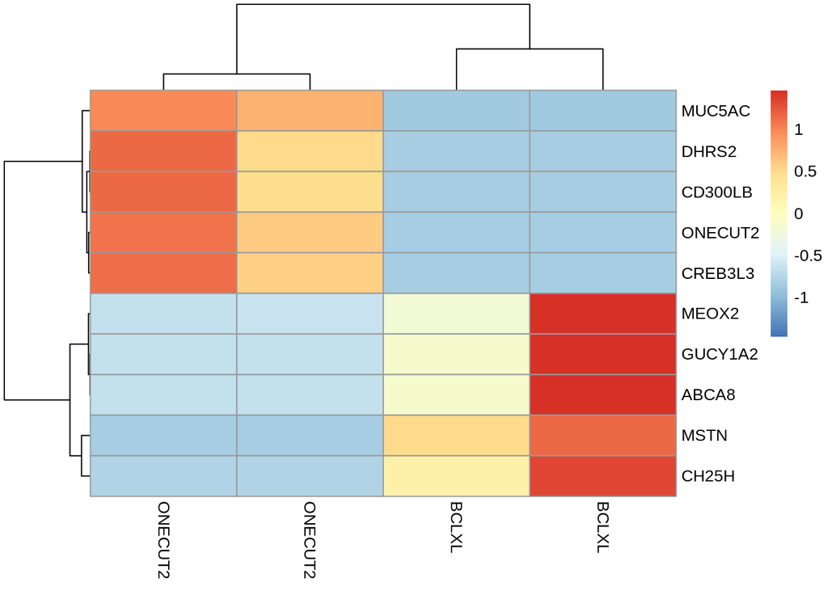

```r
#Maak een object met DE-genen symbolen
symbolen <- top_genen$symbol

# Veranderd de rijen namen voor de top 5 up- en downgereguleerde gene symbolen
rownames(count_values) <- symbolen

# Visualiseert de resultaten in de heatmap  met de DE-genen(genormaliseerd)
pheatmap(count_values, scale = "row", show_rownames = TRUE)
```

## **Cytogenetische band functie**

```r
cytogenbandToEntrex <- function(cytogen_band) {

  # Verkrijg de cytogene mapping gebaseerd op de entrex IDs voor de 10 genen.
  top_genen$chromosomal_band <- mapIds(org.Hs.eg.db,
                                       keys = top_genen$entrezid,
                                       column = "MAP",
                                       keytype = "ENTREZID",
                                       multiVals = "first")

  chromband_to_entrezid <- top_genen %>% filter(chromosomal_band == cytogen_band)
  entrezid_chromband <- chromband_to_entrezid$entrezid

  return(entrezid_chromband)
}

#Voorbeeld: chromosomal band geeft entrex id terug.
cytogenbandToEntrex("7p21.2")
```

```
## [1] "4223"
```

## **Uitvoer GO term enrichment analyse**

Zoals eerder aangegeven, ligt de interesse niet alleen bij welke genen zijn up- en downgereguleerd na behandeling, maar welke biologische processen deze genen beïnvloeden. Hiertoe wordt een **GO tern enrichment analyse** uitgevoerd. Er wordt hiervoor gebruik gemaakt van de speciale software *GOstats-pakket* in R en functie *hyperGtest()*. Zo wordt een duidelijk beeld geschetst tussen te verschillen in genexpressie in fibroblasten na behandeling met ONECUT2 of BCLXL.

Om herhalende code te voorkomen, is een functie ontworpen om de **GO term enrichment analyse** voor up- en downgereguleerde genen makkelijker en sneller uit te voeren.

### *GO term enrichment analyse functie*

```r
# GO term enrichment analysis functie

goTermAnalysis_fibroblasten <- function(dge_results, upregulated, lfc_value, padj_value) {
  # Maak een lijst van alle genen in de dataset
  all_fibroblasten_genen <- dge_results %>% data.frame() %>% rownames()
  if (upregulated==TRUE) {
    # Maak een  lijst van alle upgereguleerde genen
    upregulated_fibroblasten_genen <- dge_results %>% data.frame() %>%
      filter(log2FoldChange > lfc_value, padj < padj_value) %>% rownames()
    #Uitvoer GO term enrichment analysis
    test_object_fibroblasten_up <- new("GOHyperGParams",
                               geneIds = upregulated_fibroblasten_genen,
                               universeGeneIds = all_fibroblasten_genen,
                               annotation = "org.Hs.eg.db",
                               ontology = "BP",
                               pvalueCutoff = 1,
                               testDirection = "over")

    goterm_analysis_up_summary <- summary(hyperGTest(test_object_fibroblasten_up))
    return(goterm_analysis_up_summary)
  } else {
    # Maak een  lijst van alle downgereguleerde genen
    downregulated_fibroblasten_genen <- dge_results %>% data.frame() %>%
      filter(log2FoldChange < -lfc_value, padj < padj_value) %>% rownames()
    #Uitvoer GO term enrichment analysis
    test_object_fibroblasten_down <- new("GOHyperGParams",
                                 geneIds = downregulated_fibroblasten_genen,
                                 universeGeneIds = all_fibroblasten_genen,
                                 annotation = "org.Hs.eg.db",
                                 ontology = "BP",
                                 pvalueCutoff = 1,
                                 testDirection = "over")

    goterm_analysis_down_summary <- summary(hyperGTest(test_object_fibroblasten_down))
    return(goterm_analysis_down_summary)
  }
  }
```

Vervolgens wordt de functie uitgevoerd voor upgereguleerde genen en downgereguleerde genen met een LFC van 1 en -1 en een padj van <0.01.

### *Top 20 Upgereguleerde genen*

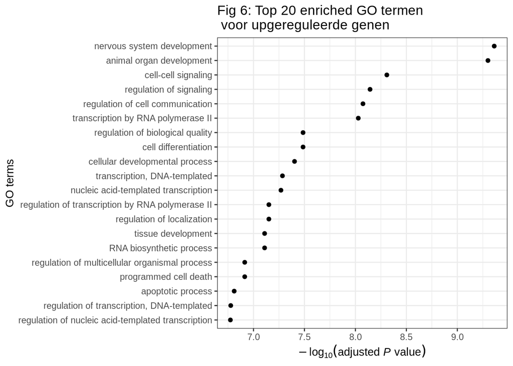

```r
#Upregulated
# Maak een dataframe met de samenvatting van de resultaten van GO term analysis
summary_fibroblasten_up_GOterm <- goTermAnalysis_fibroblasten(fibroblasten_dge_results, upregulated = TRUE, 1, 0.01)

# Pas de p-waarden aan voor meervoudige testen.
summary_fibroblasten_up_GOterm$padj <- p.adjust(summary_fibroblasten_up_GOterm$Pvalue, method = "BH")

# Selecteer alleen genensets die groter zijn dan 5 maar kleiner dan 500
# (om te voorkomen dat zeer kleine en zeer grote genensets worden meegenomen).
summary_fibroblasten_up_GOterm <- summary_fibroblasten_up_GOterm %>% filter(Count > 5) %>% filter(Count < 500)

# Kies de top 20 GO termen
goterm_analysis_up_summary_top20 <- summary_fibroblasten_up_GOterm[order(summary_fibroblasten_up_GOterm$padj)[1:20],]

# Plot  p-waardes van de top 20 uogereguleerde GO termen
goterm_analysis_up_summary_top20$Term <- factor(goterm_analysis_up_summary_top20$Term,
                                     levels = goterm_analysis_up_summary_top20$Term[
                                       order(goterm_analysis_up_summary_top20$padj, decreasing = TRUE)])

goterm_analysis_up_summary_top20 %>% ggplot(aes(x = Term, y = -log10(padj))) +
  geom_point() +
  coord_flip() +
  ylab(expression(-log[10](adjusted~italic(P)~value))) +
  xlab("GO terms") +
  ggtitle("Fig 6: Top 20 enriched GO termen\n voor upgereguleerde genen") +
  theme_bw()
```

### *Top 20 Downgereguleerde genen*

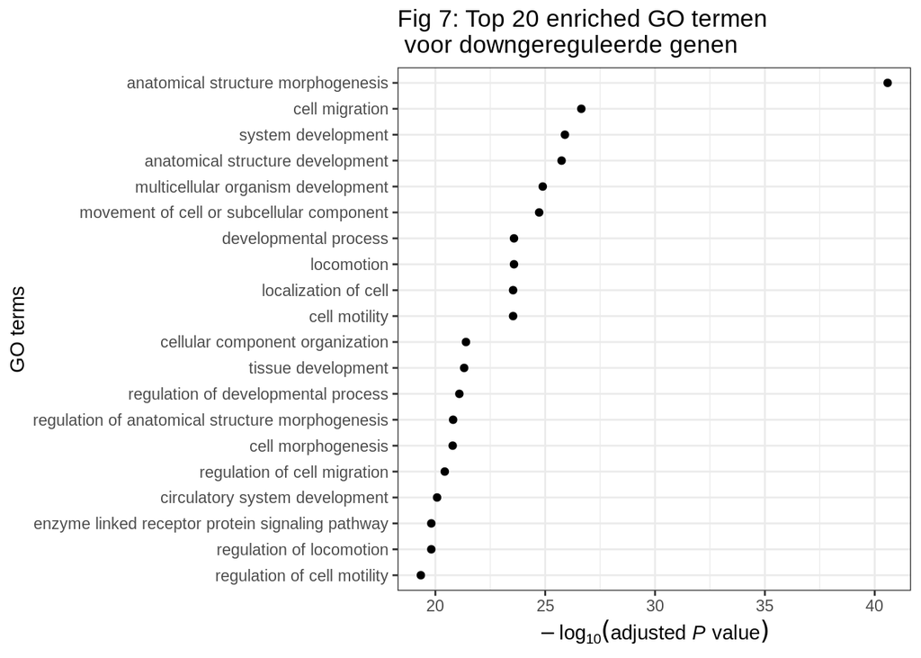

```r
#Downregulated
# Maak een dataframe met de samenvatting van de resultaten van GO term analysis
summary_fibroblasten_down_GOterm <- goTermAnalysis_fibroblasten(fibroblasten_dge_results, upregulated = FALSE, 1, 0.01)

# Pas de p-waarden aan voor meervoudige testen.
summary_fibroblasten_down_GOterm$padj <- p.adjust(summary_fibroblasten_down_GOterm$Pvalue, method = "BH")

# Selecteer alleen genensets die groter zijn dan 5 maar kleiner dan 500
# (om te voorkomen dat zeer kleine en zeer grote genensets worden meegenomen).
summary_fibroblasten_down_GOterm <- summary_fibroblasten_down_GOterm %>% filter(Count > 5) %>% filter(Count < 500)

# Kies de top 20 GO termen
goterm_analysis_down_summary_top20 <- summary_fibroblasten_down_GOterm[order(summary_fibroblasten_down_GOterm$padj)[1:20],]

# Plot  p-waardes van de top 20 downgereguleerde GO termen
goterm_analysis_down_summary_top20$Term <- factor(goterm_analysis_down_summary_top20$Term,
                                     levels = goterm_analysis_down_summary_top20$Term[
                                       order(goterm_analysis_down_summary_top20$padj, decreasing = TRUE)])

goterm_analysis_down_summary_top20 %>% ggplot(aes(x = Term, y = -log10(padj))) +
  geom_point() +
  coord_flip() +
  ylab(expression(-log[10](adjusted~italic(P)~value))) +
  xlab("GO terms") +
  ggtitle("Fig 7: Top 20 enriched GO termen\n voor downgereguleerde genen") +
  theme_bw()
```

# **Conclusie**

Op basis van de verkregen resultaten van de RNA-sequencing analyse kan er geconcludeerd worden dat **er een significant verschil is in genexpressie en biologische functies tussen fibroblasten behandeld met *BCLXL* en *ONECUT2*** . Dit wordt aangetoond door de resultaten van de **“Differential Gene Expression” analyse** en de **“GO term enrichment” analyse**.

Bij de **“Differential Gene Expression”** analyse en plots (PCA en Volcano plots), is het zichtbaar dat meerdere genen een significant verschil in hun genexpressie vertonen. Deze veranderingen in genexpressie vormen een duidelijk signaal dat er een verschil is tussen fibroblasten behandeld met *BCLXL* en *ONECUT2*.

Bij de **“GO term enrichment”** analyse, zoals zichtbaar in *figuur 6*, zijn de biologische functies die upgereguleerd worden tijdens het transdifferentiatieproces van de fibroblasten na behandeling met ONECUT2 geassocieerd met de ontwikkeling van het zenuwstelsel en organen (Development), chemische signalering (Signaling) en DNA- en RNA-transcriptie (Transcription). Deze upgereguleerde biologische functies zijn een goed signaal dat de overexpressie van de transcriptiefactor ONECUT2 ervoor zorgt dat de fibroblasten differentiëren naar hersencellen. Dit suggereert dat de **fibroblasten hun structuur veranderen en zich dus klaarmaken om andere functies uit te voeren**. Echter zien we ook dat sommige biologische functies die upgereguleerd worden tijdens het transdifferentiatieproces van de fibroblasten geassocieerd zijn met *cel-apoptose*. Dit suggereert dat de **fibroblasten zich ook klaarmaken om dood te gaan als het transdifferentiatie proces zorgt voor problemen**.

Met behulp van *figuur 7* is zichtbaar dat de biologische functies die downgereguleerd worden tijdens het transdifferentiatieproces van de fibroblasten, geassocieerd zijn met de ontwikkeling van de structuur van weefsels en cellen (Development), morfogenese van de celstructuur (Morphogenesis) en celbeweging en motiliteit. Dus **fibroblasten verliezen hun structuur en dus ook hun functie**. Dit suggereert dat de **fibroblasten zich klaarmaken om een andere structuur te krijgen en andere functies uit te voeren, zoals gebeurd bij differentiatie naar hersencellen**.

Op basis van de verkregen resultaten van de **“GO term enrichment”** analyse kan ook geconcludeerd worden dat fibroblasten behandeld met ONECUT2 van structuur veranderen en dus ook van functie. Dus **fibroblasten behandeld met ONECUT2 maken zich klaar om hersencellen te worden, echter is er ook een risico dat fibroblasten een apoptotisch proces ondergaan door complicaties tijdens het transdifferentiatie proces**.

# **Discussie**